# Anirban_INN_Bank_Churn_Full_code

### NN SMOTE and SGD Optimizer

```python
sm = SMOTE(random_state=42)
# Complete the code to fit SMOTE on the training data.
X_train_smote, y_train_smote = sm.fit_resample(X_train, y_train)
print("After UpSampling, the shape of train_X: {}".format(X_train_smote.shape))
print("After UpSampling, the shape of train_y: {} \n".format(y_train_smote.shape))
```

```
After UpSampling, the shape of train_X: (10192, 11)
After UpSampling, the shape of train_y: (10192,)
```

```python
# defining the batch size and # epochs upfront as we'll be using the same values for all models
epochs = 25
batch_size = 64
```

```python
tf.keras.backend.clear_session()
# Fixing the seed for random number generators so that we can ensure we receive the same output everytime
np.random.seed(2)
random.seed(2)
tf.random.set_seed(2)
```

```python
# Initializing the neural network
model_3 = Sequential()
model_3.add(Dense(14, activation="relu", input_dim=X_train_smote.shape[1]))
model_3.add(Dense(7, activation="relu"))
model_3.add(Dense(1, activation="sigmoid"))
```

```python
model_3.summary()
```

```
Model: "sequential"
_________________________________________________________________
 Layer (type)                Output Shape              Param #
=================================================================
 dense (Dense)               (None, 14)                168

 dense_1 (Dense)             (None, 7)                 105

 dense_2 (Dense)             (None, 1)                 8

=================================================================
Total params: 281 (1.10 KB)
Trainable params: 281 (1.10 KB)
Non-trainable params: 0 (0.00 Byte)
_________________________________________________________________
_________________________________________________________________
 Layer (type)                Output Shape              Param #
=================================================================
 dense (Dense)               (None, 14)                168

 dense_1 (Dense)             (None, 7)                 105

 dense_2 (Dense)             (None, 1)                 8

=================================================================
Total params: 281 (1.10 KB)
Trainable params: 281 (1.10 KB)
Non-trainable params: 0 (0.00 Byte)
_________________________________________________________________
```

```python
optimizer = tf.keras.optimizers.SGD(0.001)  # defining SGD as the optimizer to be used
metric = keras.metrics.Recall()
model_3.compile(loss="binary_crossentropy", optimizer=optimizer, metrics=[metric])
```

```python
model_3.summary()
```

```
Model: "sequential"
_________________________________________________________________
 Layer (type)                Output Shape              Param #
=================================================================
 dense (Dense)               (None, 14)                168

 dense_1 (Dense)             (None, 7)                 105

 dense_2 (Dense)             (None, 1)                 8

=================================================================
Total params: 281 (1.10 KB)
Trainable params: 281 (1.10 KB)
Non-trainable params: 0 (0.00 Byte)
_________________________________________________________________
_________________________________________________________________
 Layer (type)                Output Shape              Param #
=================================================================
 dense (Dense)               (None, 14)                168

 dense_1 (Dense)             (None, 7)                 105

 dense_2 (Dense)             (None, 1)                 8

=================================================================
Total params: 281 (1.10 KB)
Trainable params: 281 (1.10 KB)
Non-trainable params: 0 (0.00 Byte)
_________________________________________________________________
```

```python
import time

start = time.time()

history_3 = model_3.fit(
    X_train_smote,
    y_train_smote,
    validation_data=(X_valid, y_valid),
    batch_size=batch_size,
    epochs=epochs,
    class_weight=cw_dict,
)
end = time.time()
```

```python
print("Time taken in seconds ", end - start)
```

```
Time taken in seconds  4.54790997505188
```

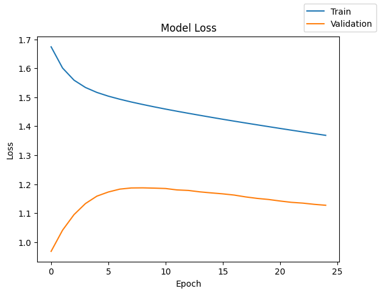

```python
plot(history_3, "loss")
```

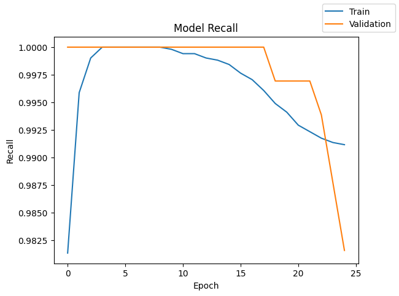

```python
plot(history_3, "recall")
```

```python
model_3_train_perf = model_performance_classification(
    model_3, X_train_smote, y_train_smote
)
model_3_train_perf
```

|  | Accuracy | Recall | Precision | F1 Score |
| --- | --- | --- | --- | --- |
| 0 | 0.539148 | 0.539148 | 0.714268 | 0.420806 |

```python
model_3_valid_perf = model_performance_classification(model_3, X_valid, y_valid)
model_3_valid_perf
```

|  | Accuracy | Recall | Precision | F1 Score |
| --- | --- | --- | --- | --- |
| 0 | 0.278125 | 0.278125 | 0.804164 | 0.214328 |

```python
# Predicting the results using best as a threshold
y_train_pred = model_3.predict(X_train_smote)
y_train_pred = y_train_pred > 0.5
y_train_pred
```

```
array([[ True],
       [ True],
       [False],
       ...,
       [ True],
       [ True],
       [ True]])
```

```python
# Predicting the results using best as a threshold
y_val_pred = model_3.predict(
    X_valid
)  ## Complete the code to make prediction on the validation set
y_val_pred = y_val_pred > 0.5
y_val_pred
```

```
array([[ True],
       [False],
       [ True],
       ...,
       [ True],
       [ True],
       [ True]])
```

```python
model_name = "NN with SMOTE & SGD"

train_metric_df.loc[model_name] = recall_score(y_train_smote, y_train_pred)
valid_metric_df.loc[model_name] = recall_score(y_valid, y_val_pred)
```

```python
# classification report
cr = classification_report(y_train_smote, y_train_pred)
print(cr)
```

```
              precision    recall  f1-score   support

           0       0.91      0.09      0.16      5096
           1       0.52      0.99      0.68      5096

    accuracy                           0.54     10192
   macro avg       0.71      0.54      0.42     10192
weighted avg       0.71      0.54      0.42     10192
```

```python
# classification report
cr = classification_report(
    y_valid, y_val_pred
)  ## Complete the code to check the model's performance on the validation set
print(cr)
```

```
              precision    recall  f1-score   support

           0       0.95      0.10      0.18      1274
           1       0.22      0.98      0.36       326

    accuracy                           0.28      1600
   macro avg       0.59      0.54      0.27      1600
weighted avg       0.80      0.28      0.21      1600
```

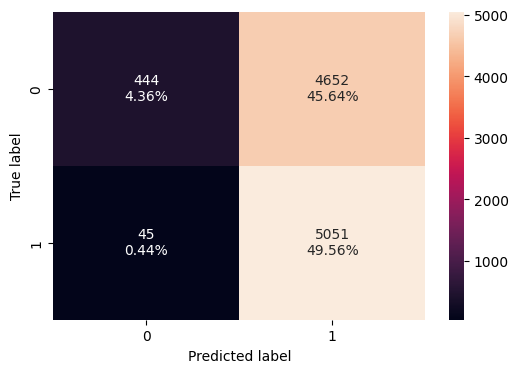

```python
make_confusion_matrix(y_train_smote, y_train_pred)
```

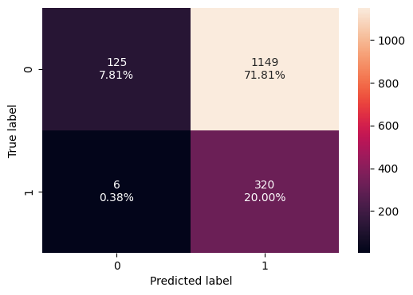

```python
make_confusion_matrix(
    y_valid, y_val_pred
)  ## Complete the code to check the model's performance on the validation set
```

### NN SMOTE and Adam Optimizer

```python
backend.clear_session()
# Fixing the seed for random number generators so that we can ensure we receive the same output everytime
np.random.seed(2)
random.seed(2)
tf.random.set_seed(2)
```

```python
# Initializing the neural network
model_4 = Sequential()
model_4.add(Dense(14, activation="relu", input_dim=X_train_smote.shape[1]))
model_4.add(Dense(7, activation="relu"))
model_4.add(Dense(1, activation="sigmoid"))
```

```python
model_4.summary()
```

```
Model: "sequential"
_________________________________________________________________
 Layer (type)                Output Shape              Param #
=================================================================
 dense (Dense)               (None, 14)                168

 dense_1 (Dense)             (None, 7)                 105

 dense_2 (Dense)             (None, 1)                 8

=================================================================
Total params: 281 (1.10 KB)
Trainable params: 281 (1.10 KB)
Non-trainable params: 0 (0.00 Byte)
_________________________________________________________________
_________________________________________________________________
 Layer (type)                Output Shape              Param #
=================================================================
 dense (Dense)               (None, 14)                168

 dense_1 (Dense)             (None, 7)                 105

 dense_2 (Dense)             (None, 1)                 8

=================================================================
Total params: 281 (1.10 KB)
Trainable params: 281 (1.10 KB)
Non-trainable params: 0 (0.00 Byte)
_________________________________________________________________
```

```python
optimizer = tf.keras.optimizers.Adam()  # defining SGD as the optimizer to be used
metric = keras.metrics.Recall()
model_4.compile(loss="binary_crossentropy", optimizer=optimizer, metrics=[metric])
```

```python
start = time.time()
history_4 = model_4.fit(
    X_train_smote,
    y_train_smote,
    validation_data=(X_valid, y_valid),
    batch_size=batch_size,
    epochs=epochs,
    class_weight=cw_dict,
)
end = time.time()
```

```python
print("Time taken in seconds ", end - start)
```

```
Time taken in seconds  4.796511173248291
```

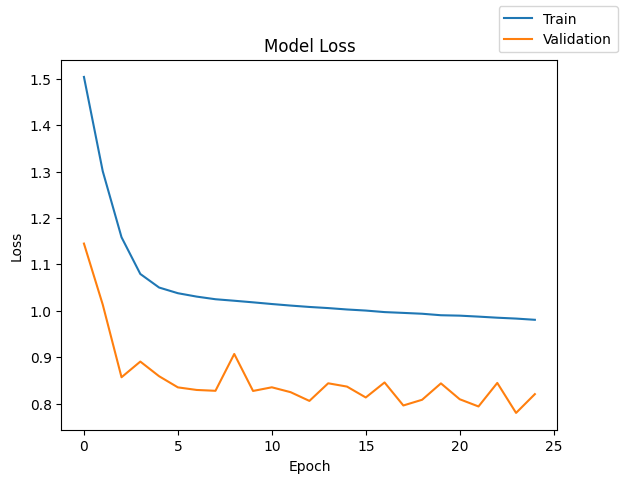

```python
plot(history_4, "loss")
```

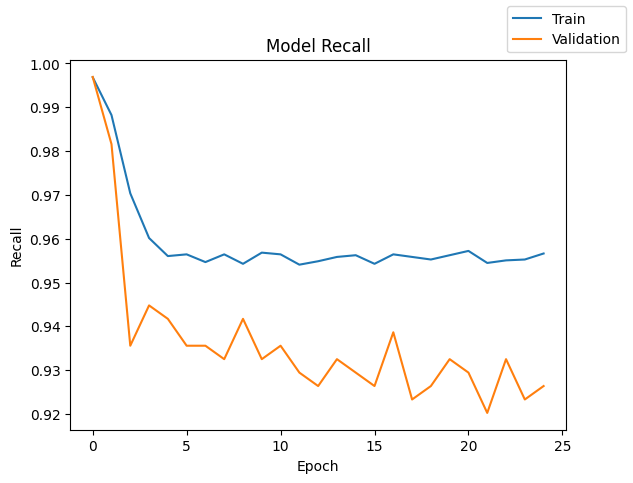

```python
plot(history_4, "recall")
```

```python
model_4_train_perf = model_performance_classification(
    model_4, X_train_smote, y_train_smote
)
model_4_train_perf
```

|  | Accuracy | Recall | Precision | F1 Score |
| --- | --- | --- | --- | --- |
| 0 | 0.734105 | 0.734105 | 0.794517 | 0.719733 |

```python
model_4_valid_perf = model_performance_classification(model_4, X_valid, y_valid)
model_4_valid_perf
```

|  | Accuracy | Recall | Precision | F1 Score |
| --- | --- | --- | --- | --- |
| 0 | 0.59 | 0.59 | 0.833437 | 0.624673 |

```python
# Predicting the results using best as a threshold
y_train_pred = model_4.predict(X_train_smote)
y_train_pred = y_train_pred > 0.5
y_train_pred
```

```
array([[ True],
       [False],
       [False],
       ...,
       [ True],
       [ True],
       [ True]])
```

```python
# Predicting the results using best as a threshold
y_val_pred = model_4.predict(
    X_valid
)  ## Complete the code to make prediction on the validation set
y_val_pred = y_val_pred > 0.5
y_val_pred
```

```
array([[ True],
       [False],
       [False],
       ...,
       [False],
       [ True],
       [ True]])
```

```python
model_name = "NN with SMOTE & Adam"

train_metric_df.loc[model_name] = recall_score(y_train_smote, y_train_pred)
valid_metric_df.loc[model_name] = recall_score(y_valid, y_val_pred)
```

```python
cr = classification_report(y_train_smote, y_train_pred)
print(cr)
```

```
              precision    recall  f1-score   support

           0       0.93      0.51      0.66      5096
           1       0.66      0.96      0.78      5096

    accuracy                           0.73     10192
   macro avg       0.79      0.73      0.72     10192
weighted avg       0.79      0.73      0.72     10192
```

```python
# classification report
cr = classification_report(
    y_valid, y_val_pred
)  ## Complete the code to check the model's performance on the validation set
print(cr)
```

```
              precision    recall  f1-score   support

           0       0.96      0.50      0.66      1274
           1       0.32      0.93      0.48       326

    accuracy                           0.59      1600
   macro avg       0.64      0.72      0.57      1600
weighted avg       0.83      0.59      0.62      1600
```

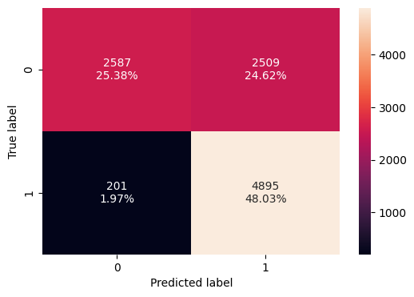

```python
make_confusion_matrix(y_train_smote, y_train_pred)
```

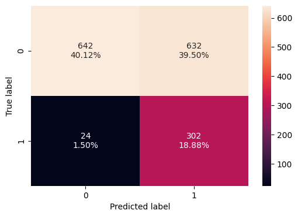

```python
make_confusion_matrix(
    y_valid, y_val_pred
)  ## Complete the code to check the model's performance on the validation set
```

```python
backend.clear_session()
# Fixing the seed for random number generators so that we can ensure we receive the same output everytime
np.random.seed(2)
random.seed(2)
tf.random.set_seed(2)
```

```python
# Initializing the neural network
model_5 = Sequential()
# Adding the input layer with 32 neurons and relu as activation function
model_5.add(Dense(32, activation="relu", input_dim=X_train_smote.shape[1]))
# Complete the code to add dropout with ratio of 0.2 or any suitable value.
model_5.add(Dropout(0.4))
# Complete the code to add a hidden layer (specify the # of neurons and the activation function)
model_5.add(Dense(7, activation="relu"))
# Complete the code to add dropout with ratio of 0.1 or any suitable value.
model_5.add(Dropout(0.2))
# Complete the code to add the number of neurons required in the output layer.
model_5.add(Dense(1, activation="sigmoid"))
```

```python
optimizer = tf.keras.optimizers.Adam()  # defining SGD as the optimizer to be used
metric = keras.metrics.Recall()
model_5.compile(loss="binary_crossentropy", optimizer=optimizer, metrics=[metric])
```

```python
start = time.time()

history_5 = model_5.fit(
    X_train,
    y_train,
    validation_data=(X_valid, y_valid),
    batch_size=batch_size,
    epochs=epochs,
    class_weight=cw_dict,
)
end = time.time()
```

```python
print("Time taken in seconds ", end - start)
```

```
Time taken in seconds  3.5261237621307373
```

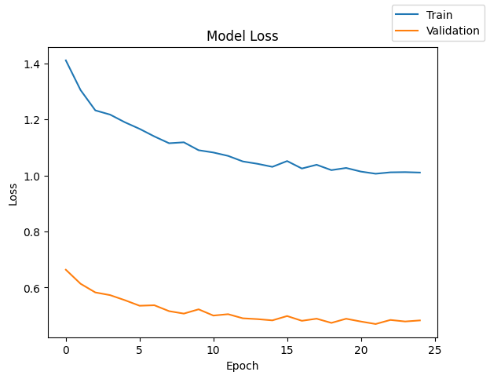

```python
plot(history_5, "loss")
```

```python
# plot(history_5, "recall")
```

```python
model_5_train_perf = model_performance_classification(
    model_2, X_train_smote, y_train_smote
)
model_5_train_perf
```

|  | Accuracy | Recall | Precision | F1 Score |
| --- | --- | --- | --- | --- |
| 0 | 0.785714 | 0.785714 | 0.786229 | 0.785618 |

```python
model_5_valid_perf = model_performance_classification(model_2, X_valid, y_valid)
model_5_valid_perf
```

|  | Accuracy | Recall | Precision | F1 Score |
| --- | --- | --- | --- | --- |
| 0 | 0.776875 | 0.776875 | 0.82589 | 0.792255 |

```python
# Predicting the results using best as a threshold
y_train_pred = model_5.predict(X_train_smote)
y_train_pred = y_train_pred > 0.5
y_train_pred
```

```
array([[ True],
       [False],
       [False],
       ...,
       [ True],
       [ True],
       [ True]])
```

```python
# Predicting the results using best as a threshold
y_val_pred = model_5.predict(
    X_valid
)  ## Complete the code to make prediction on the validation set
y_val_pred = y_val_pred > 0.5
y_val_pred
```

```
array([[False],
       [False],
       [False],
       ...,
       [False],
       [ True],
       [ True]])
```

```python
model_name = "NN with SMOTE/ Adam & Dropout"

train_metric_df.loc[model_name] = recall_score(y_train_smote, y_train_pred)
valid_metric_df.loc[model_name] = recall_score(y_valid, y_val_pred)
```

```python
# classification report
cr = classification_report(y_train_smote, y_train_pred)
print(cr)
```

```
              precision    recall  f1-score   support

           0       0.79      0.80      0.79      5096
           1       0.80      0.79      0.79      5096

    accuracy                           0.79     10192
   macro avg       0.79      0.79      0.79     10192
weighted avg       0.79      0.79      0.79     10192
```

```python
# classification report
cr = classification_report(
    y_valid, y_val_pred
)  ## Complete the code to check the model's performance on the validation set
print(cr)
```

```
              precision    recall  f1-score   support

           0       0.92      0.78      0.85      1274
           1       0.46      0.72      0.56       326

    accuracy                           0.77      1600
   macro avg       0.69      0.75      0.70      1600
weighted avg       0.82      0.77      0.79      1600
```

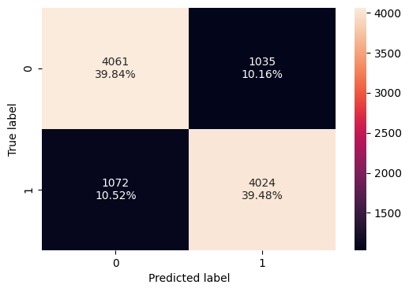

```python
make_confusion_matrix(y_train_smote, y_train_pred)
```

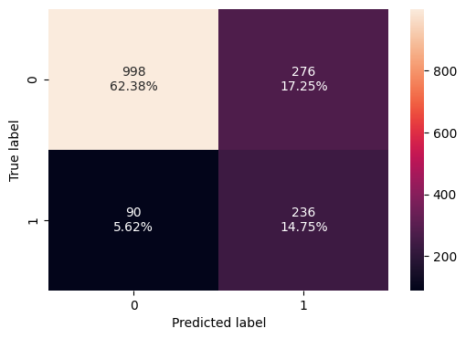

```python
make_confusion_matrix(
    y_valid, y_val_pred
)  ## Complete the code to check the model's performance on the validation set
```

## Model Performance Comparison and Final Model Selection

```python
print("Training performance comparison")
train_metric_df
```

```
Training performance comparison
```

|  | recall |
| --- | --- |
| NN with SGD | 0.675613 |
| NN with Adam | 0.526074 |
| NN with Adam & Dropout | 0.732362 |
| NN with SMOTE & SGD | 0.991170 |
| NN with SMOTE & Adam | 0.960557 |
| NN with SMOTE/ Adam & Dropout | 0.789639 |

```python
print("Validation set performance comparison")
valid_metric_df
```

```
Validation set performance comparison
```

|  | recall |
| --- | --- |
| NN with SGD | 0.659509 |
| NN with Adam | 0.423313 |
| NN with Adam & Dropout | 0.720859 |
| NN with SMOTE & SGD | 0.981595 |
| NN with SMOTE & Adam | 0.926380 |
| NN with SMOTE/ Adam & Dropout | 0.723926 |

```python
train_metric_df - valid_metric_df
```

|  | recall |
| --- | --- |
| NN with SGD | 0.016104 |
| NN with Adam | 0.102761 |
| NN with Adam & Dropout | 0.011503 |
| NN with SMOTE & SGD | 0.009574 |
| NN with SMOTE & Adam | 0.034177 |
| NN with SMOTE/ Adam & Dropout | 0.065713 |

```python
y_test_pred = model_3.predict(X_test)  ## Complete the code to specify the best model
y_test_pred = y_test_pred > 0.5
print(y_test_pred)
```

```
[[ True]
 [ True]
 [ True]
 ...
 [ True]
 [ True]
 [ True]]
```

```python
recall_score_test = recall_score(y_test, y_test_pred)
recall_score_test
```

```
0.9877149877149877
```

## Actionable Insights and Business Recommendations

- Neural Network Model with SMOTE & SGD is providing very high recall. The Data has high class imbalance as most of the records are of one particular Exited Code. hence SMOTE samples the data to alleviate this class imbalance problems and provides a better result Use this Model to predict if a customer is prone to Exit within next 3 months. If the model predicts a Yes, then initiate contact and provide offers to them to retain their account.

Power Ahead